# class4

廖昱嘉

2018年7月18日

# Is happiness correlated with open data? 的EDA

## open data跟快樂指數有關嗎?

首先，先載入dplyr和把檔案讀進來

```r
library(dplyr)
open_data<-read.csv("C:/Users/user/Desktop/codingsite/ntu-cs-x/week3/countries.csv",stringsAsFactors=F)
happiness<-read.csv("C:/Users/user/Desktop/codingsite/ntu-cs-x/week3/2015.csv",stringsAsFactors=F)
```

一般來講stringsAsFactors是默認為default.stringsAsFactors()，這裡我們要這些資料不要這樣，所以弄成F=FALSE  
接下來把“country name”轉成“country”方便資料加入另一個資料(join)!

```r
colnames(open_data)[2] <- "Country"
```

打開資料可以發現兩個資料名稱都有“country”了，可以開始join了!

```r
open_data_happiness <- open_data %>%
  left_join(happiness, by = "Country") %>%
  mutate(Country = factor(Country)) %>%
  select(Country, Region, X2015.Score, Happiness.Score, Economy..GDP.per.Capita.,
         Family, Health..Life.Expectancy., Freedom, Trust..Government.Corruption.,
         Generosity, Dystopia.Residual)
```

select()這東西使我們join的dataframe更乾淨，他只保留我們要的column!  
接下來重新命名這些column names，增加易讀性

```r
colnames(open_data_happiness) <- c("Country", "Region", "Openness", "Happiness", "GDP", "Family", "Health", "Freedom", "Trust", "Generosity", "DystopiaResidual")
```

安裝且載入formattable，開始找出前十名的opendata國家

```r
if(!require(formattable))install.packages("formattable",repos = "http://cran.us.r-project.org")
library(formattable)
open_data_happiness %>%
  arrange(desc(Openness)) %>%
  mutate_each(funs(round(., 2)), -c(Country, Region, Openness)) %>%
  head(10) %>%
  formattable(list(
    Openness = color_bar("yellow"),
    Happiness = color_bar("lightgreen"),
    GDP = color_bar("deepskyblue"),
    Family = color_bar("deepskyblue"),
    Health = color_bar("deepskyblue"),
    Freedom = color_bar("deepskyblue"),
    Trust = color_bar("deepskyblue"),
    Generosity = color_bar("deepskyblue"),
    DystopiaResidual = color_bar("deepskyblue")
  ), align = "l")
```

```
## `mutate_each()` is deprecated.
## Use `mutate_all()`, `mutate_at()` or `mutate_if()` instead.
## To map `funs` over a selection of variables, use `mutate_at()`
```

| Country | Region | Openness | Happiness | GDP | Family | Health | Freedom | Trust | Generosity | DystopiaResidual |
| --- | --- | --- | --- | --- | --- | --- | --- | --- | --- | --- |
| Taiwan | Eastern Asia | 78 | 6.30 | 1.29 | 1.08 | 0.88 | 0.40 | 0.08 | 0.25 | 2.32 |
| United Kingdom | Western Europe | 76 | 6.87 | 1.27 | 1.29 | 0.91 | 0.60 | 0.32 | 0.52 | 1.97 |
| Denmark | Western Europe | 70 | 7.53 | 1.33 | 1.36 | 0.87 | 0.65 | 0.48 | 0.34 | 2.49 |
| Colombia | Latin America and Caribbean | 68 | 6.48 | 0.92 | 1.24 | 0.69 | 0.53 | 0.05 | 0.18 | 2.86 |
| Finland | Western Europe | 67 | 7.41 | 1.29 | 1.32 | 0.89 | 0.64 | 0.41 | 0.23 | 2.62 |
| Australia | Australia and New Zealand | 67 | 7.28 | 1.33 | 1.31 | 0.93 | 0.65 | 0.36 | 0.44 | 2.27 |
| Uruguay | Latin America and Caribbean | 66 | 6.49 | 1.06 | 1.21 | 0.81 | 0.60 | 0.25 | 0.23 | 2.32 |
| United States | North America | 64 | 7.12 | 1.39 | 1.25 | 0.86 | 0.55 | 0.16 | 0.40 | 2.51 |
| Netherlands | Western Europe | 64 | 7.38 | 1.33 | 1.28 | 0.89 | 0.62 | 0.32 | 0.48 | 2.47 |
| Norway | Western Europe | 63 | 7.52 | 1.46 | 1.33 | 0.89 | 0.67 | 0.37 | 0.35 | 2.47 |

從desc可以看出他是降冪排列(畢竟要從大到小找出最高的前十名)  
mutate_each()那一行是要把所有數值變成小數點到第二位 利用formattable()來畫出圖表  
`mutate_each()` is deprecated.  
Use `mutate_all()`, `mutate_at()` or `mutate_if()` instead.  
To map `funs` over a selection of variables, use `mutate_at()`  
接下來我們要探討這些open國家是否快樂  
用圖表來呈現

```r
if(!require(ggthemes))install.packages("ggthemes",repos = "http://cran.us.r-project.org")
if(!require(viridis))install.packages("viridis",repos = "http://cran.us.r-project.org")
```

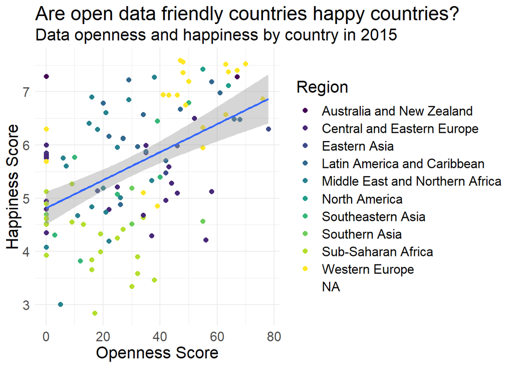

```r
library(ggplot2)
library(ggthemes)
library(viridis)
ggplot(open_data_happiness,
  aes(x = Openness,
      y = Happiness)) +
  geom_point(aes(colour = Region),
             size = 2) +
  geom_smooth(method="lm") +
  labs(x = "Openness Score",
       y = "Happiness Score",
       title = "Are open data friendly countries happy countries?",
       subtitle = "Data openness and happiness by country in 2015") +
  scale_color_viridis(discrete = T) +
  theme_minimal() +
  theme(text = element_text(size=16))
```

labs()可以使我們對這張圖給標題和副標  
從這張圖可以知道，快樂指數和資料開放度是呈正相關的(大部分國家)  
接下來要看其他指數與資料開放度的關聯

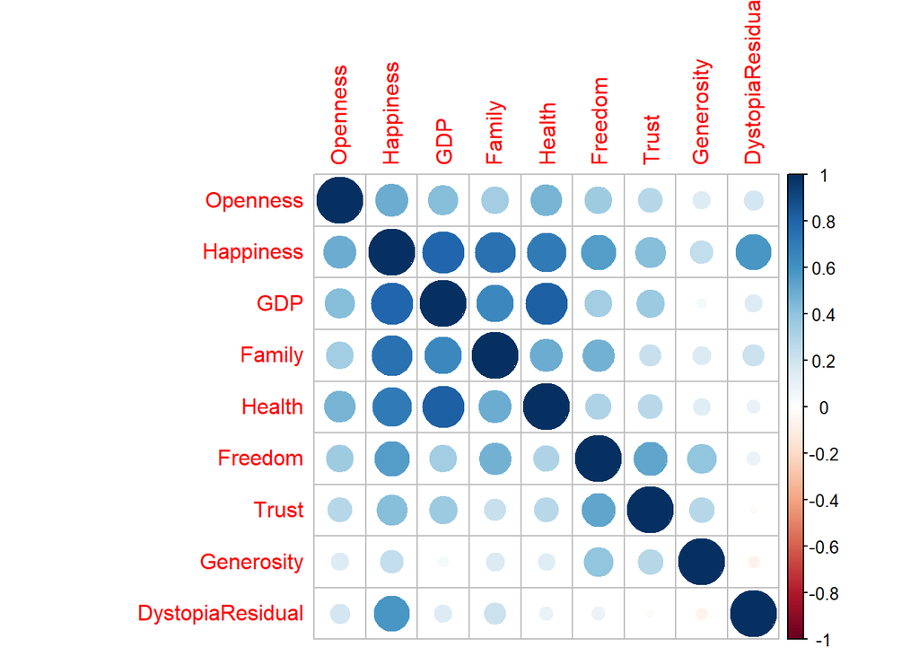

```r
if(!require(corrplot))install.packages("corrplot",repos = "http://cran.us.r-project.org")
library(corrplot)
open_data_corr <- open_data_happiness %>%
  select(Openness, Happiness, GDP, Family, Health,
         Freedom, Trust, Generosity, DystopiaResidual) %>%
  mutate(Openness = as.numeric(Openness))

od_corr <- cor(open_data_corr, use = "complete", method = "pearson")

corrplot(od_corr)
```

# 第四周的延伸

作者是比較開放度跟快樂指數的關係，我覺得開放指數應該跟人均gdp有關，所以先來畫人均gdp跟開放指數的關係吧!

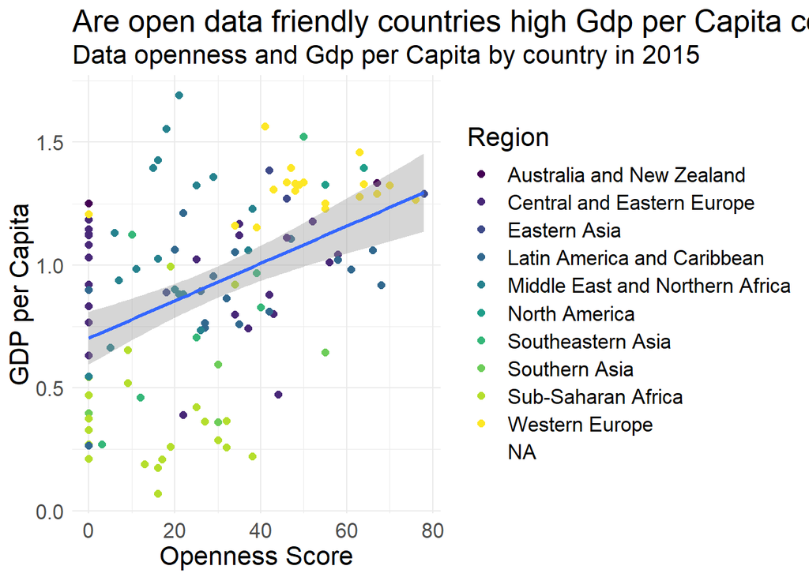

```r
ggplot(open_data_happiness,
  aes(x = Openness,
      y = GDP)) +
  geom_point(aes(colour = Region),
             size = 2) +
  geom_smooth(method="lm") +
  labs(x = "Openness Score",
       y = "GDP per Capita",
       title = "Are open data friendly countries high Gdp per Capita countries?",
       subtitle = "Data openness and Gdp per Capita by country in 2015") +
  scale_color_viridis(discrete = T) +
  theme_minimal() +
  theme(text = element_text(size=16))
```

再來確認他的correlation!!!

```r
library(dplyr)
open_data_happiness %>%
  filter(!is.na(GDP),!is.na(Openness))%>%
  summarise(N=n(),r=cor(Openness,GDP))
```

```
##     N         r
## 1 118 0.4272795
```

0.4272795!他是正相關沒錯，可惜是只有0.4多而已，相關性並不強，所以我覺得他可能開放性跟人均gdp沒有太大關係，那或許openness跟國家的Trust (Government Corruption)有關???圖先畫了再說!

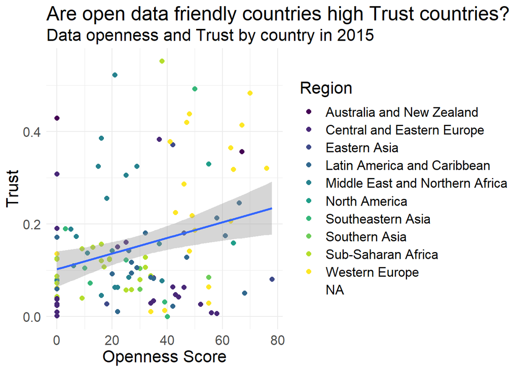

```r
ggplot(open_data_happiness,
  aes(x = Openness,
      y = Trust)) +
  geom_point(aes(colour = Region),
             size = 2) +
  geom_smooth(method="lm") +
  labs(x = "Openness Score",
       y = "Trust",
       title = "Are open data friendly countries high Trust countries?",
       subtitle = "Data openness and Trust by country in 2015") +
  scale_color_viridis(discrete = T) +
  theme_minimal() +
  theme(text = element_text(size=16))
```

確認一下他的correlation!

```r
open_data_happiness %>%
  filter(!is.na(Trust),!is.na(Openness))%>%
  summarise(N=n(),r=cor(Openness,Trust))
```

```
##     N         r
## 1 118 0.2819576
```

0.2819576!也是正相關，可惜更低了，所以政府信任度和資料開放度也不是我們要找的相關性高目標，接下來比較自由度與開放度的關係。

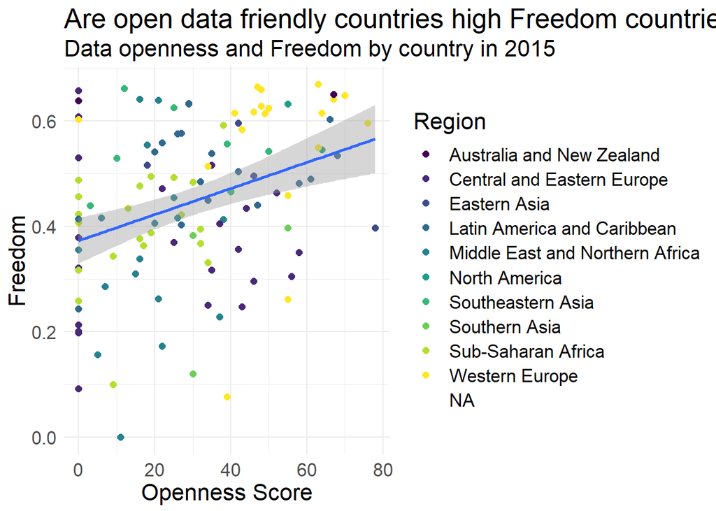

```r
ggplot(open_data_happiness,
  aes(x = Openness,
      y = Freedom)) +
  geom_point(aes(colour = Region),
             size = 2) +
  geom_smooth(method="lm") +
  labs(x = "Openness Score",
       y = "Freedom",
       title = "Are open data friendly countries high Freedom countries?",
       subtitle = "Data openness and Freedom by country in 2015") +
  scale_color_viridis(discrete = T) +
  theme_minimal() +
  theme(text = element_text(size=16))
```

一樣確認他的correlation!

```r
open_data_happiness %>%
  filter(!is.na(Freedom),!is.na(Openness))%>%
  summarise(N=n(),r=cor(Openness,Freedom))
```

```
##     N         r
## 1 118 0.3522194
```

0.3522194!也是正相關只是也沒有很高!  
既然都沒有甚麼關係，那來從區域來分吧，看看哪區域的人比較快樂!

```r
library(Hmisc)
```

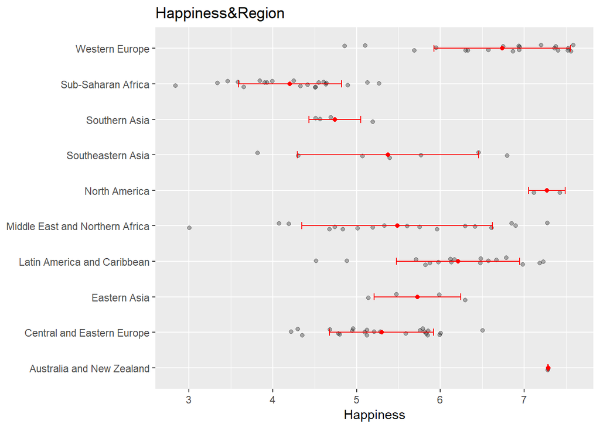

```r
open_data_happiness %>%
  filter(!is.na(Region))%>%
  ggplot(aes(x=Region,y=Happiness))+
  geom_jitter(width=0.1,alpha=0.3)+
  stat_summary(geom="point",fun.y=mean,col="red")+
  stat_summary(geom="errorbar",fun.data=mean_sdl,fun.args=list(mult=1),
               width=0.2,col="red")+
  labs(y="Happiness",title="Happiness&Region")+
  theme(axis.title.y=element_blank())+
  coord_flip()
```

再來做做看區域與人均gdp

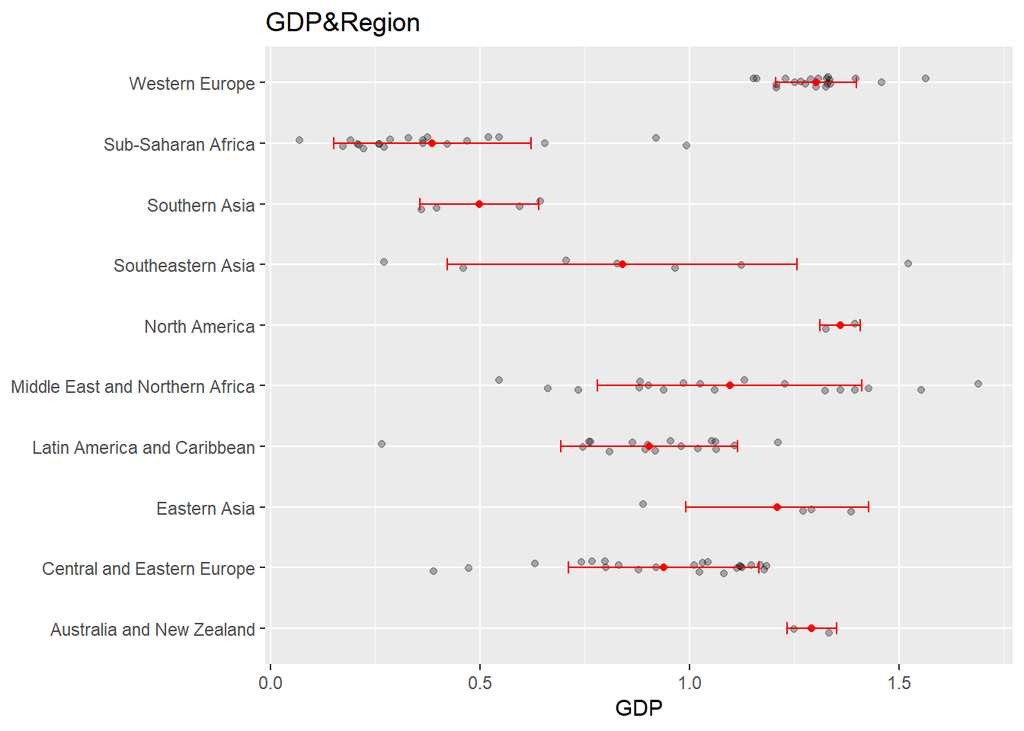

```r
open_data_happiness %>%
  filter(!is.na(Region))%>%
  ggplot(aes(x=Region,y=GDP))+
  geom_jitter(width=0.1,alpha=0.3)+
  stat_summary(geom="point",fun.y=mean,col="red")+
  stat_summary(geom="errorbar",fun.data=mean_sdl,fun.args=list(mult=1),
               width=0.2,col="red")+
  labs(y="GDP",title="GDP&Region")+
  theme(axis.title.y=element_blank())+
  coord_flip()
```

發現兩張圖好像差不多，所以來做人均GDP跟快樂程度的關係圖

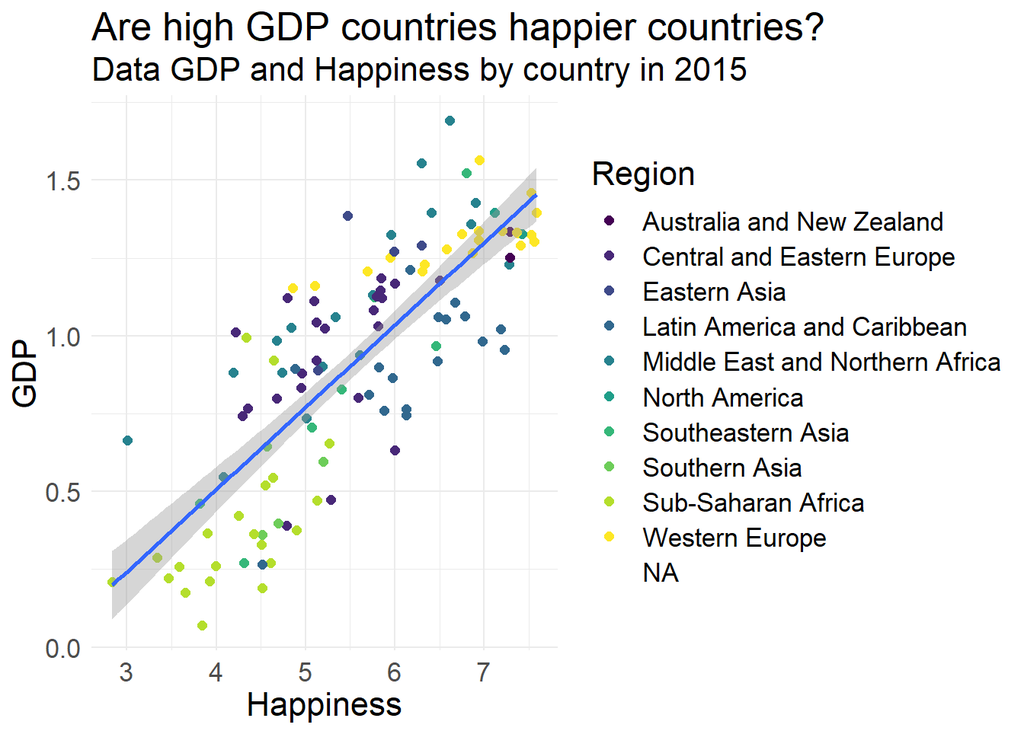

```r
ggplot(open_data_happiness,
  aes(x = Happiness,
      y = GDP)) +
  geom_point(aes(colour = Region),
             size = 2) +
  geom_smooth(method="lm") +
  labs(x = "Happiness",
       y = "GDP",
       title = "Are high GDP countries happier countries?",
       subtitle = "Data GDP and Happiness by country in 2015") +
  scale_color_viridis(discrete = T) +
  theme_minimal() +
  theme(text = element_text(size=16))
```

再來算算他的correlation!

```r
open_data_happiness %>%
  filter(!is.na(GDP),!is.na(Happiness))%>%
  summarise(N=n(),r=cor(GDP,Happiness))
```

```
##     N         r
## 1 118 0.7963946
```

高達將近0.8!!!可見人均gdp越高國家越快樂…

```r
choose<-open_data_happiness%>%
  filter(Region=="Western Europe"|Region=="Australia and New Zealand")
t.test(GDP~Region,data=choose)
```

```
##
##  Welch Two Sample t-test
##
## data:  GDP by Region
## t = -0.23943, df = 1.6015, p-value = 0.8378
## alternative hypothesis: true difference in means is not equal to 0
## 95 percent confidence interval:
##  -0.2699846  0.2474996
## sample estimates:
## mean in group Australia and New Zealand
##                                1.291880
##            mean in group Western Europe
##                                1.303122
```

```r
t.test(Happiness~Region,data=choose)
```

```
##
##  Welch Two Sample t-test
##
## data:  Happiness by Region
## t = 3.0013, df = 19.001, p-value = 0.007341
## alternative hypothesis: true difference in means is not equal to 0
## 95 percent confidence interval:
##  0.1651264 0.9261736
## sample estimates:
## mean in group Australia and New Zealand
##                                 7.28500
##            mean in group Western Europe
##                                 6.73935
```

```r
anova(m1<-lm(Openness~Region,data=open_data_happiness))
```

```
## Analysis of Variance Table
##
## Response: Openness
##            Df Sum Sq Mean Sq F value    Pr(>F)
## Region      9  17245 1916.08  5.5159 3.129e-06 ***
## Residuals 108  37517  347.38
## ---
## Signif. codes:  0 '***' 0.001 '**' 0.01 '*' 0.05 '.' 0.1 ' ' 1
```

3.129e-06<0.05所以各組平均值有明顯差異!!!

```r
anova(m2<-lm(Happiness~Region,data=open_data_happiness))
```

```
## Analysis of Variance Table
##
## Response: Happiness
##            Df Sum Sq Mean Sq F value    Pr(>F)
## Region      9 90.056 10.0062   16.07 < 2.2e-16 ***
## Residuals 108 67.248  0.6227
## ---
## Signif. codes:  0 '***' 0.001 '**' 0.01 '*' 0.05 '.' 0.1 ' ' 1
```

2.2e-16<0.05所以各組平均值有明顯差異!!!

```r
anova(m3<-lm(GDP~Region,data=open_data_happiness))
```

```
## Analysis of Variance Table
##
## Response: GDP
##            Df  Sum Sq Mean Sq F value    Pr(>F)
## Region      9 11.2356 1.24840  22.156 < 2.2e-16 ***
## Residuals 108  6.0855 0.05635
## ---
## Signif. codes:  0 '***' 0.001 '**' 0.01 '*' 0.05 '.' 0.1 ' ' 1
```

2.2e-16<0.05所以各組平均值有明顯差異!!!  
接下來來做回歸直線  
先來把區域跟gdp做點計算

```r
library(coefplot)
open_data_happiness <-filter(open_data_happiness,!is.na(Region))
open_data_happiness$Region<-factor(open_data_happiness$Region,
                                   levels=c("Western Europe",
                                            "North America",
                                            "Australia and New Zealand",
                                            "Middle East and Northern Africa",
                                            "Latin America and Caribbean",
                                            "Central and Eastern Europe",
                                            "Southeastern Asia",
                                            "Eastern Asia",
                                            "Sub-Saharan Africa",
                                            "Southern Asia"
                                   ))
tapply(open_data_happiness$GDP, open_data_happiness$Region, mean)
```

```
##                  Western Europe                   North America
##                       1.3031225                       1.3604000
##       Australia and New Zealand Middle East and Northern Africa
##                       1.2918800                       1.0962222
##     Latin America and Caribbean      Central and Eastern Europe
##                       0.9047329                       0.9389343
##               Southeastern Asia                    Eastern Asia
##                       0.8398100                       1.2094700
##              Sub-Saharan Africa                   Southern Asia
##                       0.3864710                       0.4994800
```

接下來畫畫看同區域的gdp，加上信賴區間

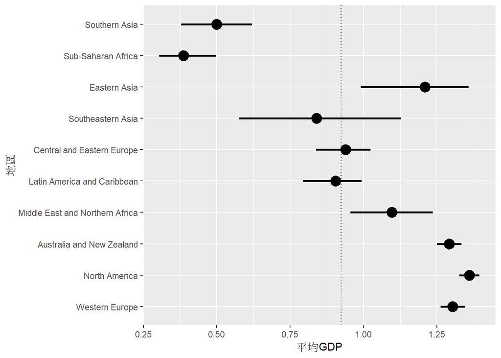

```r
ggplot(data = open_data_happiness,
       aes(x = Region, y = open_data_happiness$GDP)) +
  stat_summary(fun.data = 'mean_cl_boot', size = 1) +
  geom_hline(yintercept = mean(open_data_happiness$GDP) ,
             linetype = 'dotted') +
  labs(x = '地區', y = '平均GDP') +
  coord_flip()
```

猜測GDP在各區是因為跟快樂指數有關

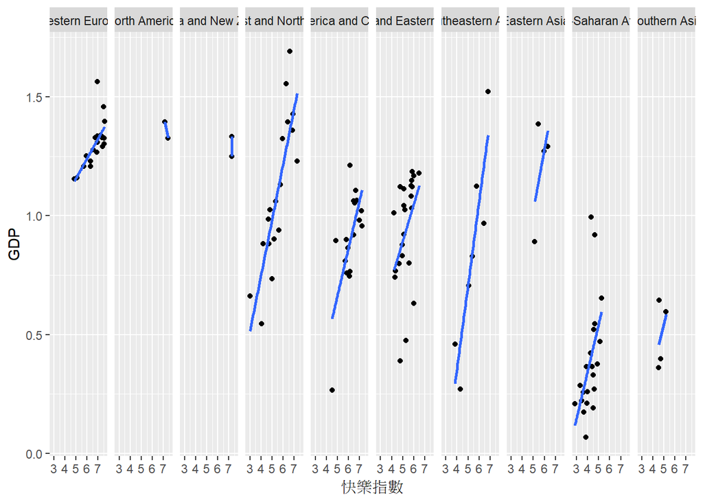

```r
ggplot(data = open_data_happiness,
       aes(group = Region,
          y = GDP, x = Happiness)) +
  geom_point() +
  stat_smooth(method = 'lm', se = F) +
  stat_smooth(aes(group = Region,
          y = GDP, x =  Happiness),
          method = 'lm', se = F) +
  facet_grid( . ~  Region) +
  labs(x = '快樂指數', y = 'GDP')
```

正式開始畫圖囉<sub>~</sub>

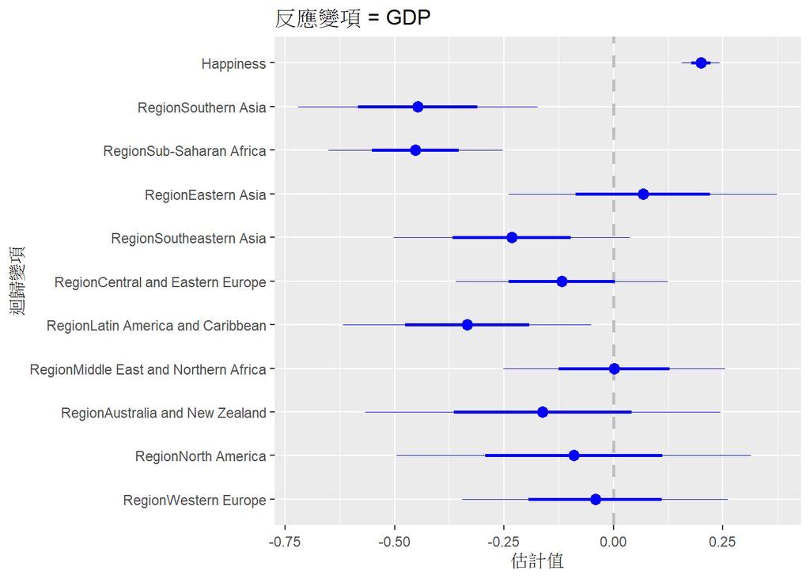

```r
m2 <- lm(GDP ~ Region+Happiness- 1,
         data = open_data_happiness)
coefplot(m2, xlab = '估計值', ylab = '迴歸變項', title = '反應變項 = GDP')
```

把資料與迴歸分析的預測值、殘差與影響度放進資料

```r
fit_m2 <- data.frame(open_data_happiness[, c("Region","GDP", "Happiness")], fitted = fitted(m2), resid = resid(m2),
                     infl = influence(m2)$hat )
```

依地區疊合真實觀測值與預測值

[figure not shown]

```r
ggplot(data = fit_m2, aes(x = GDP, group = Region )) +
 stat_density(geom = 'path', position = 'identity') +
 stat_density(geom = 'path', position = 'identity', aes(x = fitted)) +
 geom_vline(xintercept = c(with(open_data_happiness, tapply(GDP,Region, mean))), linetype = 'dotted')+
 facet_grid(Region ~ .) +
 labs(x = 'GDP', y = '機率密度')
```

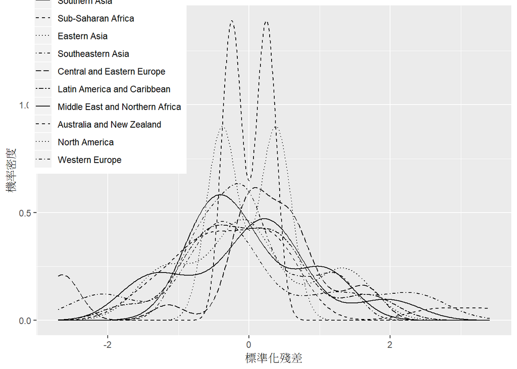

```r
ggplot(data = fit_m2, aes(x = scale(resid)), group = Region ) +
 stat_density(geom = 'path', position = 'identity', aes(linetype = Region)) +
 scale_linetype_manual(values = 10:1) +
 guides(linetype = guide_legend(reverse = TRUE)) +
 labs(x = '標準化殘差', y = '機率密度') +
 theme(legend.position = c(.15, .8))
```

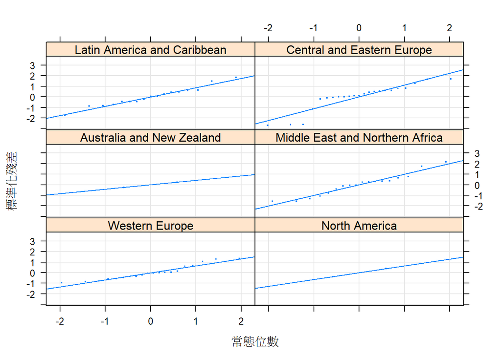

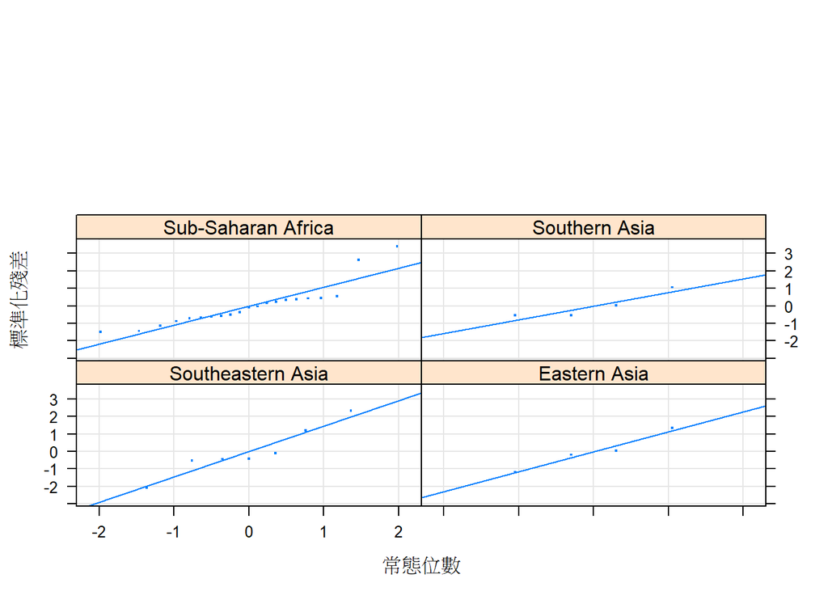

```r
require(lattice)
qqmath(~ scale(resid) | Region, data = fit_m2, type = c('p', 'g', 'r'),
       xlab = '常態位數', ylab = '標準化殘差', layout = c(2, 3),
       pch = '.', cex = 2)
```

畫預測值與殘差的散佈圖，檢查線性與等分散假設

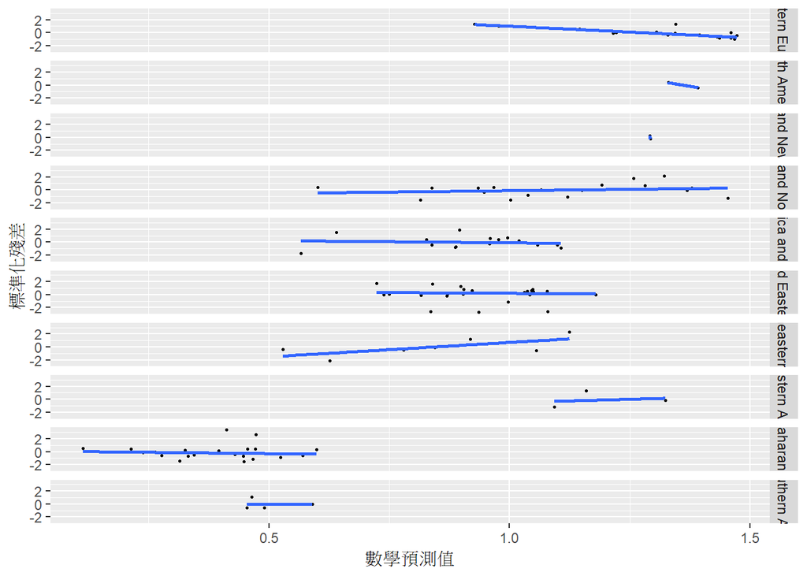

```r
library(ggplot2)
require(MASS)
ggplot(data = fit_m2, aes(x = fitted, y = scale(resid), group = Region )) +
  geom_point(pch = 20, size = 1) +
  stat_smooth(method = 'rlm', se = F) +
  facet_grid(Region ~ .) +
  labs(x = '數學預測值', y = '標準化殘差')
```

呈現影響值（影響估計結果過大的值）與標準化殘差

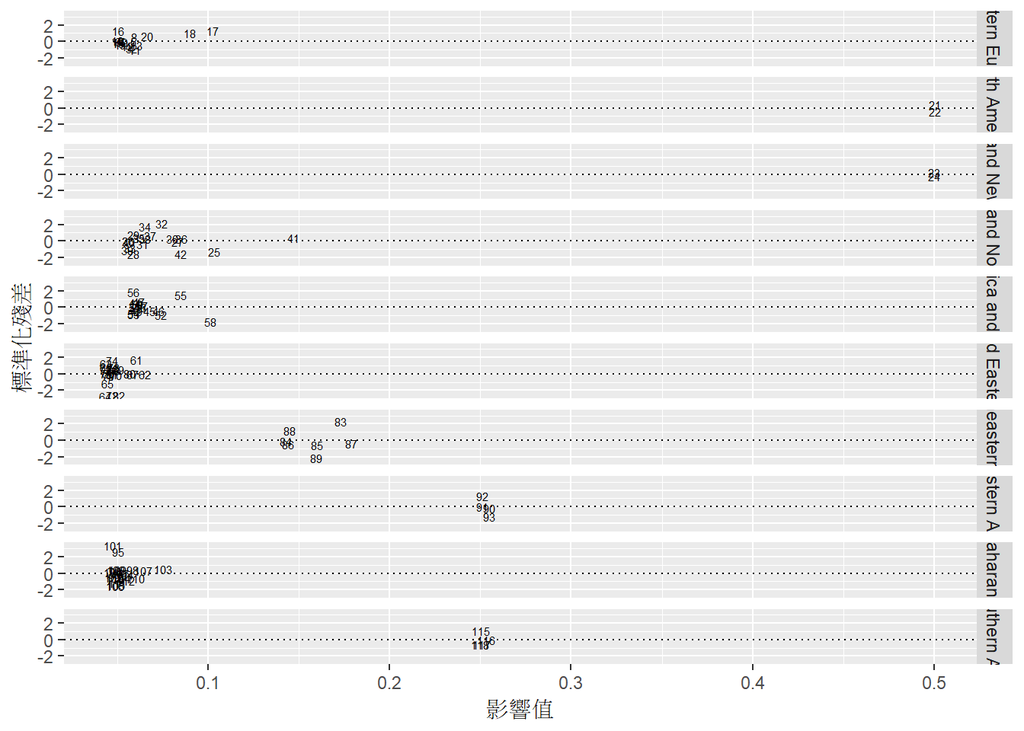

```r
ggplot(data = fit_m2, aes(x = infl, y = scale(resid), group = Region)) +
 geom_text(aes(label = rownames(fit_m2)), cex = 2) +
 geom_hline(yintercept = 0, linetype = 'dotted') +
 facet_grid(Region ~ .) +
 labs(x = '影響值', y = '標準化殘差')
```

看看影響值

```r
summary(influence(m2)$hat)
```

```
##    Min. 1st Qu.  Median    Mean 3rd Qu.    Max.
## 0.04348 0.05027 0.05893 0.09322 0.07514 0.50035
```

接下來分析資料集當中的其他變項是否和GDP有關

```r
open_data_happiness_gdp<-open_data_happiness[,c("GDP","Happiness","Openness","Freedom","Trust","Health")]
```

看看基本統計量

```r
colMeans(open_data_happiness_gdp)
```

```
##        GDP  Happiness   Openness    Freedom      Trust     Health
##  0.9229264  5.5755339 28.9322034  0.4450297  0.1513408  0.6785086
```

呈現兩兩散佈圖

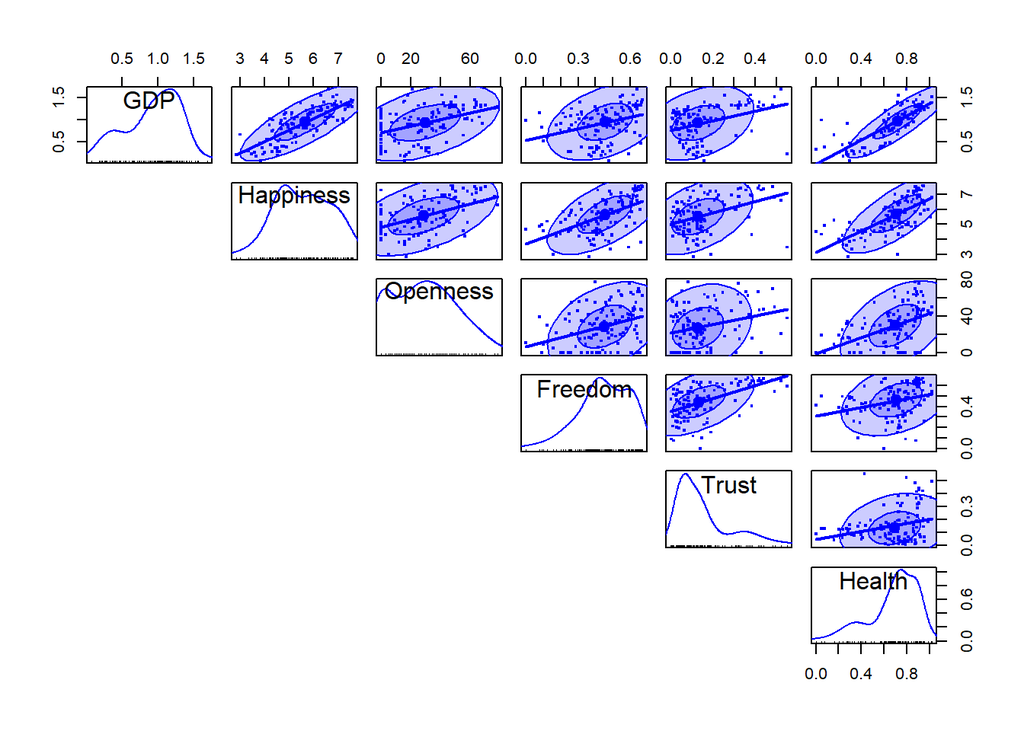

```r
require(heplots)
scatterplotMatrix(~ GDP + Happiness + Openness + Freedom+Trust+Health, data= open_data_happiness_gdp,
  pch = '.', cex = 3, smooth = FALSE, reg.line = FALSE, ellipse = TRUE,
  diagonal = 'none', lower.panel = NULL)
```

我們利用corrplot 套件，以圖形顯示相關性的大小

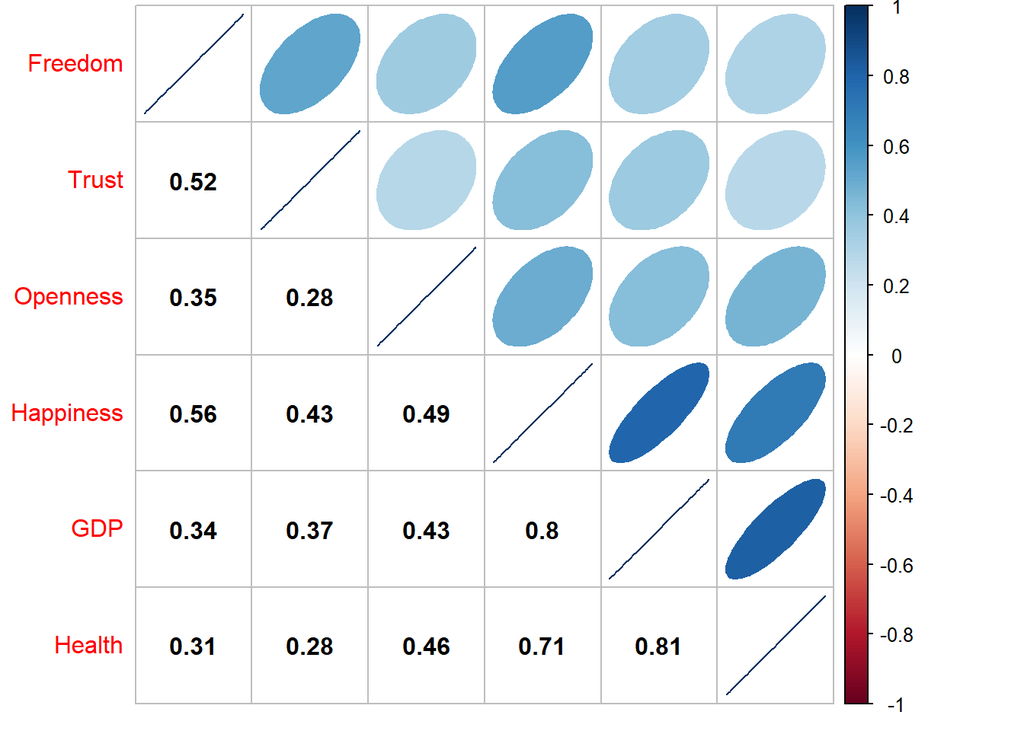

```r
require(corrplot)
corrplot(cor(open_data_happiness_gdp), method = 'ellipse', order = 'hclust', addrect = 6,
         type = 'upper', tl.pos = 'tp')
corrplot(cor(open_data_happiness_gdp), add = TRUE, type = 'lower', method = 'number',
         order = 'hclust', col = 'black', diag = FALSE, tl.pos = 'n', cl.pos = 'n')
```

放進五個解釋變項

```r
summary(m4 <- lm(GDP ~ Happiness + Openness + Freedom+Trust+Health, data = open_data_happiness_gdp))
```

```
##
## Call:
## lm(formula = GDP ~ Happiness + Openness + Freedom + Trust + Health,
##     data = open_data_happiness_gdp)
##
## Residuals:
##      Min       1Q   Median       3Q      Max
## -0.37384 -0.09880  0.00229  0.11234  0.80714
##
## Coefficients:
##               Estimate Std. Error t value Pr(>|t|)
## (Intercept) -0.4333112  0.0910637  -4.758 5.87e-06 ***
## Happiness    0.1616308  0.0253321   6.380 4.10e-09 ***
## Openness    -0.0003654  0.0009548  -0.383   0.7027
## Freedom     -0.2952440  0.1524954  -1.936   0.0554 .
## Trust        0.2680616  0.1611912   1.663   0.0991 .
## Health       0.8201134  0.1121605   7.312 4.19e-11 ***
## ---
## Signif. codes:  0 '***' 0.001 '**' 0.01 '*' 0.05 '.' 0.1 ' ' 1
##
## Residual standard error: 0.1892 on 112 degrees of freedom
## Multiple R-squared:  0.7684, Adjusted R-squared:  0.7581
## F-statistic: 74.33 on 5 and 112 DF,  p-value: < 2.2e-16
```

畫圖看成效

```r
require(effects)
```

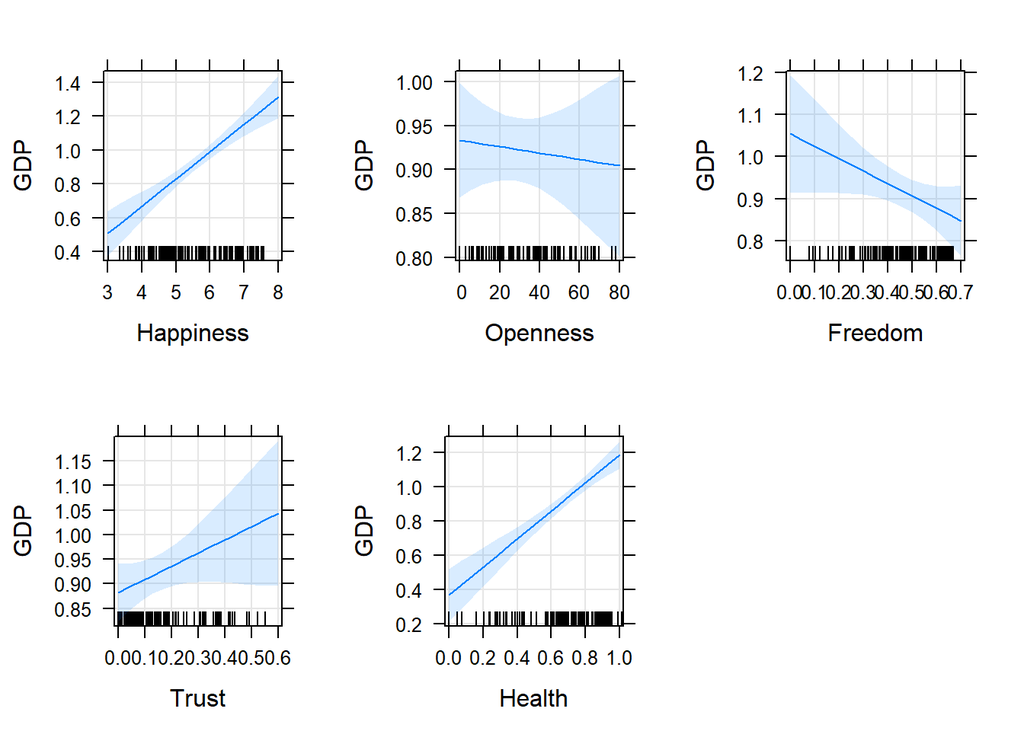

```r
plot(allEffects(m4), main = '', grid = T)
```

從這幾張圖跟前面幾張圖，都可以了解到跟gdp最有關連的都是快樂指數和健康指數，他們的正相關性都非常高(0.8以上)，其他(開放度、政府信任度、自由度)不但相關性低，還有呈現負相關的，可見其他這三個可能都跟gdp沒有太大的關係。  
利用 lm.beta 套件，計算標準化迴歸係數

```r
library(lm.beta)
summary(lm.beta(m4))
```

```
##
## Call:
## lm(formula = GDP ~ Happiness + Openness + Freedom + Trust + Health,
##     data = open_data_happiness_gdp)
##
## Residuals:
##      Min       1Q   Median       3Q      Max
## -0.37384 -0.09880  0.00229  0.11234  0.80714
##
## Coefficients:
##               Estimate Standardized Std. Error t value Pr(>|t|)
## (Intercept) -0.4333112    0.0000000  0.0910637  -4.758 5.87e-06 ***
## Happiness    0.1616308    0.4870879  0.0253321   6.380 4.10e-09 ***
## Openness    -0.0003654   -0.0205431  0.0009548  -0.383   0.7027
## Freedom     -0.2952440   -0.1165911  0.1524954  -1.936   0.0554 .
## Trust        0.2680616    0.0906460  0.1611912   1.663   0.0991 .
## Health       0.8201134    0.4871372  0.1121605   7.312 4.19e-11 ***
## ---
## Signif. codes:  0 '***' 0.001 '**' 0.01 '*' 0.05 '.' 0.1 ' ' 1
##
## Residual standard error: 0.1892 on 112 degrees of freedom
## Multiple R-squared:  0.7684, Adjusted R-squared:  0.7581
## F-statistic: 74.33 on 5 and 112 DF,  p-value: < 2.2e-16
```

看看控制其他(開放度 政府信任度 自由度)因素後，gdp的效果

```r
summary(m5 <- update(m4, . ~ . -Openness- Freedom -Trust , data = open_data_happiness_gdp))
```

```
##
## Call:
## lm(formula = GDP ~ Happiness + Health, data = open_data_happiness_gdp)
##
## Residuals:
##      Min       1Q   Median       3Q      Max
## -0.38291 -0.11485 -0.00606  0.09140  0.78305
##
## Coefficients:
##             Estimate Std. Error t value Pr(>|t|)
## (Intercept) -0.46593    0.08737  -5.333 4.90e-07 ***
## Happiness    0.14689    0.02159   6.805 4.83e-10 ***
## Health       0.83990    0.10952   7.669 6.09e-12 ***
## ---
## Signif. codes:  0 '***' 0.001 '**' 0.01 '*' 0.05 '.' 0.1 ' ' 1
##
## Residual standard error: 0.1909 on 115 degrees of freedom
## Multiple R-squared:  0.758,  Adjusted R-squared:  0.7538
## F-statistic: 180.1 on 2 and 115 DF,  p-value: < 2.2e-16
```

```r
anova(m5, m4)
```

```
## Analysis of Variance Table
##
## Model 1: GDP ~ Happiness + Health
## Model 2: GDP ~ Happiness + Openness + Freedom + Trust + Health
##   Res.Df    RSS Df Sum of Sq      F Pr(>F)
## 1    115 4.1916
## 2    112 4.0111  3   0.18049 1.6799 0.1754
```

總結:  
從第三周的作業，可以知道快樂指數是和開放度有關的，雖然他的correlation是正相關沒錯，但非常的低，而第四周的各種畫圖與計算，可以發現，真正與快樂指數最相關的其實是GDP啊!!!尤其是大洋洲兩國(澳洲、紐西蘭)和西歐區，他們都過得很爽(gdp高快樂指數高健康指數高)，而近一步從多個變數(政府開放度、信任度…)可以發現gdp總是跟快樂指數和健康指數成高度正相關(0.8左右)，再輔以回歸線佐證，我們可以發現這三者是非常有關連的，因此從這次的分析，我得出結論，gdp高的地區往往會更快樂與更健康。